# Regression Models

## Simple linear regression

Since the project is interested in exploring the relationship between transmission type and MPG, it’s logical for me to start with simple linear regression with transmission type (am) as the sole independent variable.

```r
fit1 <- lm(mpg ~ am, data = data)
linear1<-summary(fit1)
linear1$coef
```

```
##              Estimate Std. Error   t value     Pr(>|t|)
## (Intercept) 17.147368   1.124603 15.247492 1.133983e-15
## ammn         7.244939   1.764422  4.106127 2.850207e-04
```

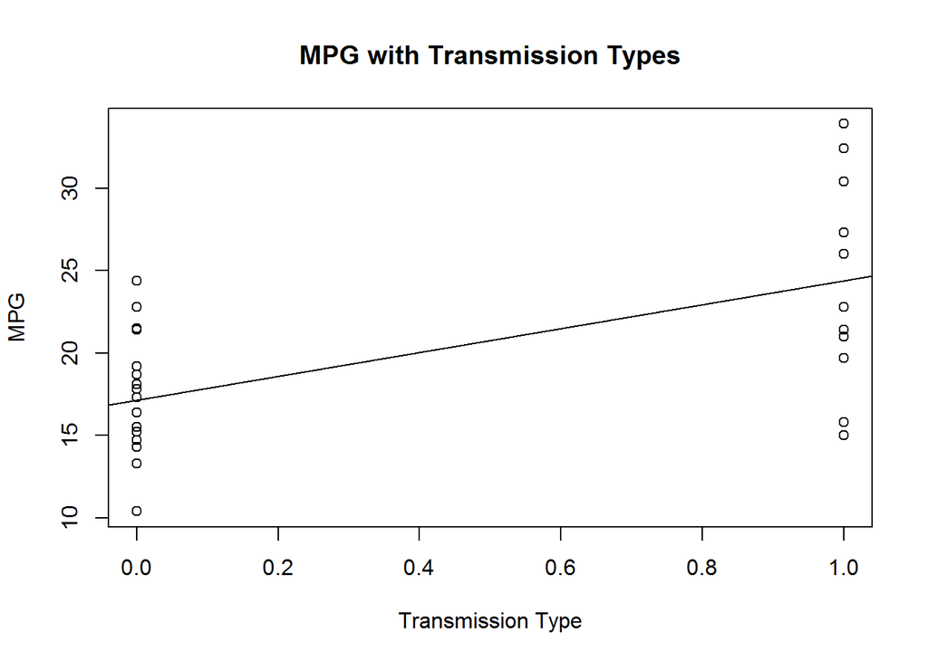

```r
plot(mtcars$am, mtcars$mpg, main = "MPG with Transmission Types",
     xlab = "Transmission Type", ylab = "MPG")
abline(fit1)
```

According to the regression, manual transmission cars generally would have 7.24 higher mpg than the cars with automatic transmission, which have an average mpg of 17.15. This suggests, in term of mpg, cars with manual transmission would in general have better performance. The p-value for the differences is much smaller than 5%, thus I have more than 95% confidence that the cars with manual transmission will have different mpg mean from the cars with automatic transmission.

## Multivariable regression

Based on the earlier exploratory analysis, we know that there will be a lot of collinearity exist among regressors if we use all of them, because some of the variables in this dataset are highly correlated to each other.

In order to identify the varibles which have strong correlations, I calculated the correlations between 10 regressors, and draw a heatmap to identify the variables have similar correlations with other regressors. The assumptions are that there are no other available regressors, and the variables with similar correlations with other regressors should carry the similar information to the model.

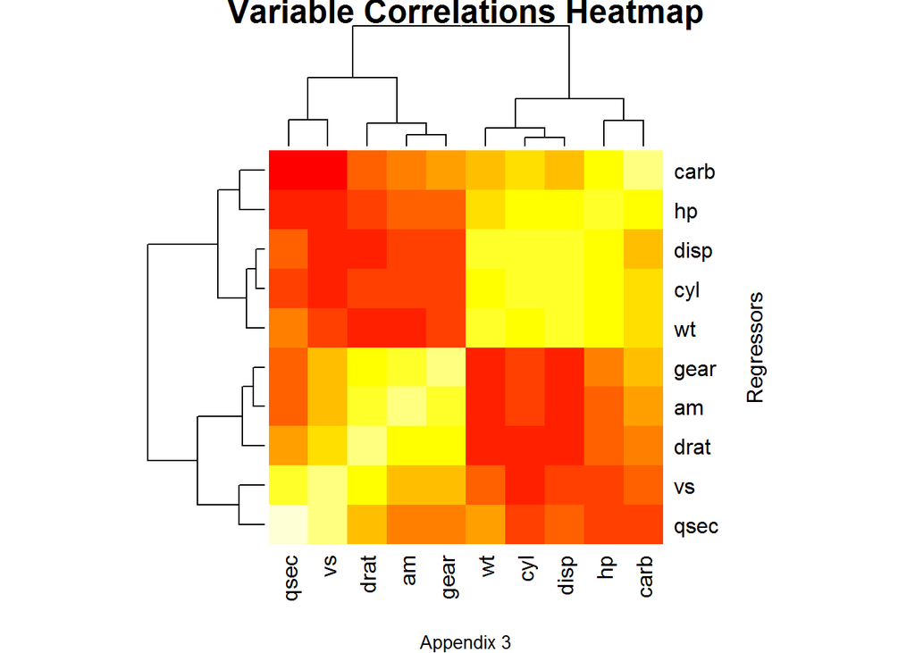

```r
n <- length(mtcars)
cormt <- matrix(0, n-1, n-1)
colnames(cormt)<-colnames(data)[2:n]
rownames(cormt)<-colnames(data)[2:n]
for (i in 2:n){
        for (j in 2:n){
                cormt[i-1,j-1] <- cor(mtcars[,i], mtcars[,j])
        }
}
heatmap(cormt, main = "Variable Correlations Heatmap", ylab = "Regressors",
        sub = "Appendix 3")
```

As the heatmap showed, there are generally 4 types of regressors, type 1 has carb and hp, type 2 has disp, cyl and wt, type 3 has gear, am and drat, and type 4 has vs and qsec. Using the following code, I fit linear models for all possible combinations, and find the combination achieves the minimum Sigma, or residual standard error.

```r
fit <- matrix(0, 36, 5)
colnames(fit)<-c("R1","R2","R3","R4","Sigma"); x <- 0
for (i in c(11, 4)){
        for (j in c(3,2,6)){
                for (m in c(10,9,5)){
                        for (n in c(8,7)){
                                y<-summary(lm(data$mpg~data[,i]+data[,j]+data[,m]+data[,n]))
                                x <- x +1
                                fit[x,1] <- i; fit[x,2] <- j; fit[x,3] <- m
                                fit[x,4] <- n; fit[x,5] <- y$sigma
                        }
                }
        }
}
colnames(data)[fit[which(fit[,5] == min(fit[,5])),1:4]]
```

```
## [1] "hp"   "wt"   "am"   "qsec"
```

The model acheived the lowest residual standard error with hp, wt, am and qsec as regressor. fit the linear model with those regressor.

```r
fit2 <- lm(mpg~ hp + wt + am + qsec, data = data)
linear2 <- summary(fit2)
linear2$coef
```

```
##                Estimate Std. Error   t value    Pr(>|t|)
## (Intercept) 17.44019110  9.3188688  1.871492 0.072149342
## hp          -0.01764654  0.0141506 -1.247052 0.223087932
## wt          -3.23809682  0.8898986 -3.638726 0.001141407
## ammn         2.92550394  1.3971471  2.093913 0.045790788
## qsec         0.81060254  0.4388703  1.847021 0.075731202
```

The p-value of coefficient of regressor hp is much higher than 5%, thus its impact is not significant, when other regressors hold constant. Refit the model without regressor hp.

```r
fit3 <- lm(mpg~ wt + am + qsec, data = data)
linear3 <- summary(fit3)
linear3$coef
```

```
##              Estimate Std. Error   t value     Pr(>|t|)
## (Intercept)  9.617781  6.9595930  1.381946 1.779152e-01
## wt          -3.916504  0.7112016 -5.506882 6.952711e-06
## ammn         2.935837  1.4109045  2.080819 4.671551e-02
## qsec         1.225886  0.2886696  4.246676 2.161737e-04
```

Every regressor has significant impact on the mpg. Fit a new model with intersepts of three regressors.

```r
fit4 <- lm(mpg~ wt + am + qsec + wt*am + am*qsec + qsec*wt, data = data)
linear4 <- summary(fit4)
linear4$coef
```

```
##                Estimate Std. Error    t value    Pr(>|t|)
## (Intercept) -31.8598140 33.5894244 -0.9485073 0.351950704
## wt            9.8361860  9.8094164  1.0027290 0.325598997
## ammn         21.7150538 15.8498376  1.3700490 0.182851089
## qsec          3.3187634  1.8349518  1.8086379 0.082551306
## wt:ammn      -4.7165458  1.6643036 -2.8339456 0.008964866
## ammn:qsec    -0.3536353  0.7094109 -0.4984915 0.622495265
## wt:qsec      -0.7113650  0.5424688 -1.3113474 0.201657327
```

The intersept of wt and am has significant impact on the model, however, the intersept of am and qsec, and the intersept of qsec and wt do not have significant impact on the model. Therefore, I refit the model with mt, am, qsec and the intersept of wt and am.

```r
fit5 <- lm(mpg~ wt + am + qsec + wt*am, data = data)
linear5 <- summary(fit5)
linear5$coef
```

```
##              Estimate Std. Error   t value     Pr(>|t|)
## (Intercept)  9.723053  5.8990407  1.648243 0.1108925394
## wt          -2.936531  0.6660253 -4.409038 0.0001488947
## ammn        14.079428  3.4352512  4.098515 0.0003408693
## qsec         1.016974  0.2520152  4.035366 0.0004030165
## wt:ammn     -4.141376  1.1968119 -3.460340 0.0018085763
```

```r
sigma <- vector()
sigma[1] <- linear1$sigma
sigma[2] <- linear2$sigma
sigma[3] <- linear3$sigma
sigma[4] <- linear4$sigma
sigma[5] <- linear5$sigma
names(sigma)<-c("Model 1","Model 2", "Model 3", "Model 4", "Model 5")
sigma
```

```
##  Model 1  Model 2  Model 3  Model 4  Model 5
## 4.902029 2.434828 2.458846 2.087849 2.084122
```

The final multivariable regression model has a residual standard error of 2.08, which is the lowest among all five models. Appendix 4 lists the residual standard errors for all five models. However, the coeficient of intercept in this model is not statistically significant.

## Interpretation

In order to help interpretation, I changed the data, specifically the wt and qsec variables, using the following code.

```r
data2 <- data[,c(1,6,7,9)]
data2$wt <- data2$wt/2 - 1      #Adjust the weight unit to ton, and adjust the zero value to 1 ton
data2$qsec <- data2$qsec - 14   #Adjust the zero value of qsec to 14 seconds
fit6 <- lm(mpg~ wt + am + qsec + wt*am, data = data2)
linear6 <- summary(fit6)
linear6
```

```
##
## Call:
## lm(formula = mpg ~ wt + am + qsec + wt * am, data = data2)
##
## Residuals:
##     Min      1Q  Median      3Q     Max
## -3.5076 -1.3801 -0.5588  1.0630  4.3684
##
## Coefficients:
##             Estimate Std. Error t value Pr(>|t|)
## (Intercept)   18.088      1.874   9.650 3.03e-10 ***
## wt            -5.873      1.332  -4.409 0.000149 ***
## ammn           5.797      1.454   3.987 0.000458 ***
## qsec           1.017      0.252   4.035 0.000403 ***
## wt:ammn       -8.283      2.394  -3.460 0.001809 **
## ---
## Signif. codes:  0 '***' 0.001 '**' 0.01 '*' 0.05 '.' 0.1 ' ' 1
##
## Residual standard error: 2.084 on 27 degrees of freedom
## Multiple R-squared:  0.8959, Adjusted R-squared:  0.8804
## F-statistic: 58.06 on 4 and 27 DF,  p-value: 7.168e-13
```

In this final model, the coefficient of intercept suggests that when a car weight one ton, with automatic transmission, and has a 1/4 mile time of 14 seconds, the car’s mpg is expected to be 18.09. The coefficient of wt suggests that when a car has automatic transmission, and has a 1/4 mile time of 14 seconds, the car’s mpg will decrease -5.87 for every ton of weight increase. The coefficient of am suggests that when a car weight one ton, and has a 1/4 mile time of 14 seconds, the car’s mpg would be 5.8 higher if the car has a manual transmission instead of automatic transmission. The coefficient of qsec suggests that when a car weight one ton, and has automatic transmission, for every one second increase in 1/4 mile time, its mpg would increase by 1.02. The coefficient of the intercept of wt and am suggests that when a car has a 1/4 mile time of 14 seconds, the manual transmission will accelerate the speed of decrease in mpg for each tone of weight by 8.28.